# Problem Set 8

Ilayda Koca

2022-11-11

## Getting Set Up

If you haven’t already, create a folder for this course, and then a subfolder within for the second lecture `Topic9_Clustering`, and two additional subfolders within `code` and `data`.

Open `RStudio` and create a new RMarkDown file (`.Rmd`) by going to `File -> New File -> R Markdown...`. Change the title to `"DS1000: Problem Set 8"` and the author to your full name. Save this file as `[LAST NAME]_ps8.Rmd` to your `code` folder.

If you haven’t already, download the `FederalistPaperCorpusTidy.Rds` file from the course [github page](https://github.com/jbisbee1/DS1000-F2022/blob/master/Lectures/Topic9_Clustering/data/CountyVote2004_2020.Rds) and save it to your `data` folder.

Require `tidyverse`, `tidytext`, and load the `FederalistPaperCorpusTidy.Rds` data to `corpus.tidy`.

```r
require(tidyverse)
require(tidytext)
corpus.tidy <-  readRDS('../data/FederalistPaperCorpusTidy.Rds')
```

## Question 1 [4 points]

Calculate the degree to which Madison or Hamilton use a given word by calculating the ratio of Hamilton’s use to Madison’s use. To do this, start by converting the data into a “bag of words” (BOW) structure using the `unnest_tokens()` function from the `tidytext` package. Make sure to remove any numbers! Then calculate the frequency that either Hamilton or Madison used each word, and finally calculate the ratio of Hamilton to Madison. Now remove any words that appear fewer than 20 times, and then plot the top-10 most Hamilton-specific words and the top-10 most Madison-specific words. Do you see any interesting patterns?

```r
tokens <- corpus.tidy %>%
  unnest_tokens(output = word, input = text,
                token = "word_stems") %>%
  mutate(word = str_replace_all(word, "\\d+", "")) %>%
  filter(word != "")
```

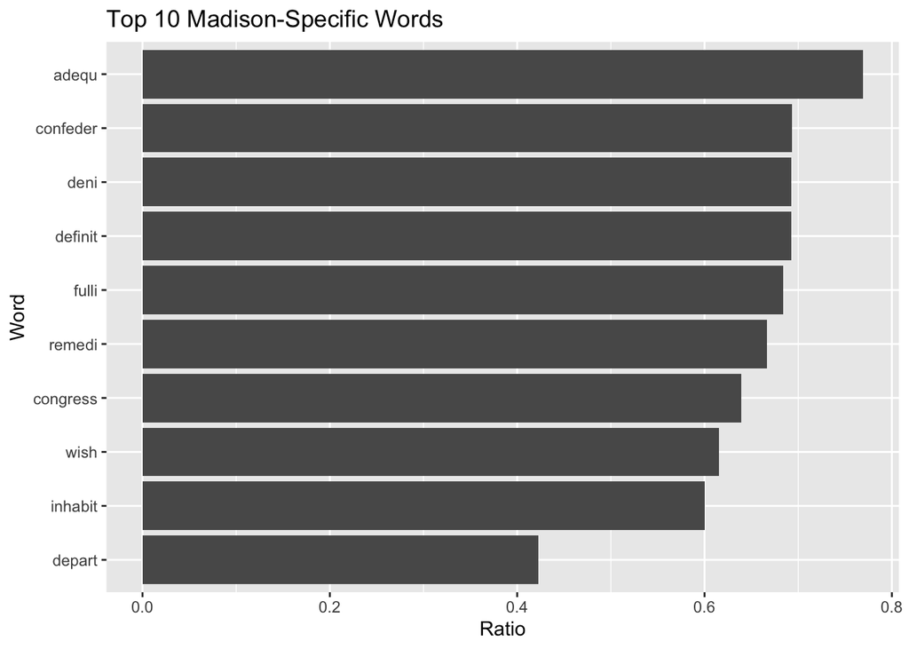

```r
author_ratio <- tokens %>%
  count(author, word) %>%
  filter(author %in% c('hamilton', 'madison')) %>%
  spread(author, n) %>%
  rowwise() %>%
  mutate(ratio = hamilton / madison, total = sum(hamilton, madison, na.rm=T))

madison_words <- author_ratio %>%
  filter(total > 20 & (ratio > 5 | ratio < 1) & ratio != "Inf") %>%
  arrange(ratio)

hamilton_words <- author_ratio %>%
  filter(total > 20 & (ratio > 5 | ratio < 1) & ratio != "Inf") %>%
  arrange(ratio)

madison_words %>%
  ungroup() %>%
  arrange(ratio) %>%
  slice(1:10) %>%
  ggplot(aes(x = ratio, y = reorder(word, ratio))) +
  geom_bar(stat = "identity") +
  labs(x = 'Ratio',
       y = 'Word',
       title = 'Top 10 Madison-Specific Words')
```

```r
madison_words
```

```
## # A tibble: 171 × 5
## # Rowwise:
##    word     hamilton madison ratio total
##    <chr>       <int>   <int> <dbl> <int>
##  1 depart         41      97 0.423   138
##  2 inhabit         9      15 0.6      24
##  3 wish            8      13 0.615    21
##  4 congress       39      61 0.639   100
##  5 remedi         10      15 0.667    25
##  6 fulli          13      19 0.684    32
##  7 definit         9      13 0.692    22
##  8 deni            9      13 0.692    22
##  9 confeder       43      62 0.694   105
## 10 adequ          10      13 0.769    23
## # … with 161 more rows
```

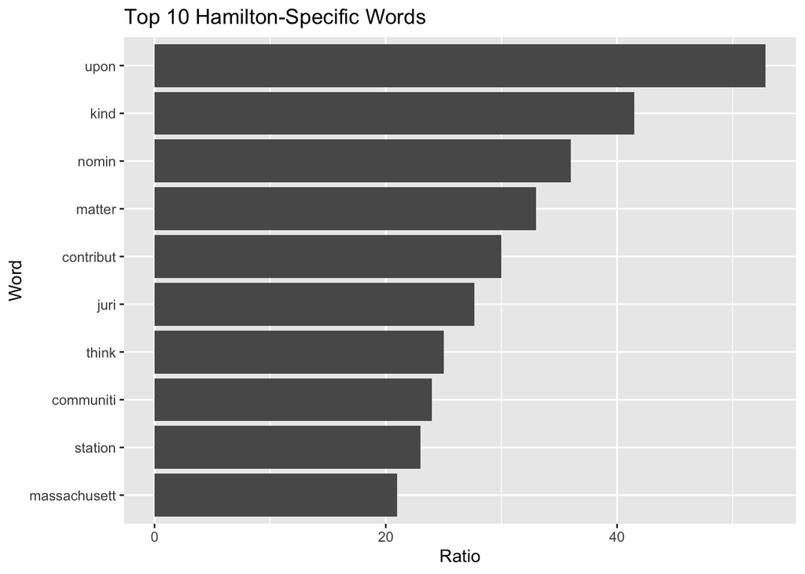

```r
hamilton_words %>%
  ungroup() %>%
  arrange(-ratio) %>%
  slice(1:10) %>%
  ggplot(aes(x = ratio, y = reorder(word, ratio))) +
  geom_bar(stat = "identity") +
  labs(x = 'Ratio',
       y = 'Word',
       title = 'Top 10 Hamilton-Specific Words')
```

```r
hamilton_words
```

```
## # A tibble: 171 × 5
## # Rowwise:
##    word     hamilton madison ratio total
##    <chr>       <int>   <int> <dbl> <int>
##  1 depart         41      97 0.423   138
##  2 inhabit         9      15 0.6      24
##  3 wish            8      13 0.615    21
##  4 congress       39      61 0.639   100
##  5 remedi         10      15 0.667    25
##  6 fulli          13      19 0.684    32
##  7 definit         9      13 0.692    22
##  8 deni            9      13 0.692    22
##  9 confeder       43      62 0.694   105
## 10 adequ          10      13 0.769    23
## # … with 161 more rows
```

> - Madison’s use of words of confeder, congress, inhabit, depart indicate that Madison might be talking about the Civil War. Hamilton uses th words contribut, station, communiti indicates that he is focusing on issues regarding America as a nation.

## Question 2 [4 points]

Now **wrangle** the data in order to run a regression in which you predict either Hamilton or Madison authorship as a function of the rate at which the top-5 most specific words for each author are used in each document. To do this, you first must create a document term matrix (DTM) and calculate the rate at which words are used (calculate the rate per 1,000 words for this step). Then you must spread the data so that you have a dataset you can use for regression analysis, in which each row is a document, and each column is a word, and the values are the rate at which that word is used in that document. Be careful to change the name of the `author` column to avoid replacing it with the rate at which the word `author` appears in the data! Also make sure to replace missing data (`NA`) with zeros! Finally, recode author so that the outcome is numeric, and is +1 if the author is Hamilton, and is -1 if the author is Madison, and is `NA` otherwise.

```r
dtm <- tokens %>%
  count(author,document,word) %>% # create a document-term matrix
  group_by(document) %>%
  mutate(totWords = sum(n)) %>% # Calculate the total words
  ungroup() %>%
  mutate(rate = n*1000 / totWords) # Calculate the rate at which a word is used

dat <- dtm %>%
  select(-n) %>%
  rename(authorFOUNDER = author) %>%
  spread(word,rate) # Spread

dat <- dat %>%
  mutate_at(vars(-authorFOUNDER,-document,-totWords),
            function(wrd) ifelse(is.na(wrd),0,wrd))
dat
```

```
## # A tibble: 85 × 4,983
##    authorF…¹ docum…² totWo…³     a abandon  abat   abb  abet abhorr  abil abject
##    <chr>       <int>   <int> <dbl>   <dbl> <dbl> <dbl> <dbl>  <dbl> <dbl>  <dbl>
##  1 contested      49    1643  20.1       0 0         0     0  0     0          0
##  2 contested      50    1099  12.7       0 0         0     0  0     0          0
##  3 contested      51    1911  24.1       0 0         0     0  0     0          0
##  4 contested      52    1841  19.0       0 0         0     0  0     0.543      0
##  5 contested      53    2161  22.2       0 0.463     0     0  0     0          0
##  6 contested      54    1995  17.5       0 0         0     0  0     0          0
##  7 contested      55    2037  23.6       0 0         0     0  0     0          0
##  8 contested      56    1560  30.8       0 0         0     0  0     0          0
##  9 contested      57    2203  16.8       0 0         0     0  0.454 0          0
## 10 contested      62    2381  31.5       0 0         0     0  0     0          0
## # … with 75 more rows, 4,972 more variables: abl <dbl>, ablest <dbl>,
## #   abolish <dbl>, abolit <dbl>, abort <dbl>, abound <dbl>, about <dbl>,
## #   abov <dbl>, abridg <dbl>, abroad <dbl>, abrog <dbl>, absenc <dbl>,
## #   absolut <dbl>, absolv <dbl>, absorb <dbl>, abstain <dbl>, abstract <dbl>,
## #   abstrus <dbl>, absurd <dbl>, abund <dbl>, abus <dbl>, abyss <dbl>,
## #   acced <dbl>, acceler <dbl>, accept <dbl>, access <dbl>, accid <dbl>,
## #   accident <dbl>, accommod <dbl>, accomod <dbl>, accompani <dbl>, …
```

## Question 3 [4 points]

Finally, run the regression and use the model to predict authorship on the full data. Visualize the results by plotting the list of Federalist papers on the x-axis and the predicted authorship on the y-axis, coloring points by whether they were authored by Madison, Hamilton, or are contested papers. According to this analysis, who most likely authored the contested documents? EXTRA CREDIT: calculate the 100-fold cross validated RMSE with an 80-20 split, and then express your predictions about authorship in terms of lower and upper bounds. `set.seed(123)` for consistency.

```r
datSubset_ham5 <- dat %>%
  select(author = authorFOUNDER, # select() can rename variables with the =
         document,
         hamilton_words$word[1:5]) # Only grabbing the top 10 words favored by Hamilton
datSubset_ham5
```

```
## # A tibble: 85 × 7
##    author    document depart inhabit  wish congress remedi
##    <chr>        <int>  <dbl>   <dbl> <dbl>    <dbl>  <dbl>
##  1 contested       49  8.52    0     0.609    0      0.609
##  2 contested       50  2.73    0     0        0      1.82
##  3 contested       51  7.33    0     0.523    0      0.523
##  4 contested       52  0       0.543 0        0.543  0.543
##  5 contested       53  0       0     0        0.463  0
##  6 contested       54  0       5.51  0        0.501  0
##  7 contested       55  0       0.491 0        1.96   0
##  8 contested       56  0       1.92  0        0.641  0
##  9 contested       57  0.454   0.454 0        0.908  0
## 10 contested       62  0       0     0.420    0      0
## # … with 75 more rows
```

```r
train <- datSubset_ham5 %>%
  filter(author == 'hamilton'|author == 'madison') %>% # subsetting to documents written by either of the two authors we're interested in
  mutate(score = ifelse(author == 'hamilton',1,-1)) # Creating a continuous outcome that is +1 for Hamilton and -1 for Madison
train
```

```
## # A tibble: 66 × 8
##    author   document depart inhabit  wish congress remedi score
##    <chr>       <int>  <dbl>   <dbl> <dbl>    <dbl>  <dbl> <dbl>
##  1 hamilton        1  0       0     0.632    0      0         1
##  2 hamilton        6  0       0.516 0        0      0.516     1
##  3 hamilton        7  0       0.444 0        0.444  0         1
##  4 hamilton        8  0       0.504 0        0      0         1
##  5 hamilton        9  0.507   0     0        0      0         1
##  6 hamilton       11  0       0.402 0        0      0         1
##  7 hamilton       12  0       0     0        0      0         1
##  8 hamilton       13  1.04    0     0        0      0         1
##  9 hamilton       15  0       0     0        0.325  0.325     1
## 10 hamilton       16  0       0     0.492    0      0.492     1
## # … with 56 more rows
```

```r
form <- paste0('score ~ ',paste(hamilton_words$word[1:5],collapse = ' + '))
form
```

```
## [1] "score ~ depart + inhabit + wish + congress + remedi"
```

```r
mHam <- lm(as.formula(form),train)
summary(mHam)
```

```
##
## Call:
## lm(formula = as.formula(form), data = train)
##
## Residuals:
##      Min       1Q   Median       3Q      Max
## -1.66366 -0.04699  0.06910  0.29176  1.17851
##
## Coefficients:
##             Estimate Std. Error t value Pr(>|t|)
## (Intercept)  1.04699    0.10215  10.250 8.34e-15 ***
## depart      -0.09860    0.02841  -3.471 0.000966 ***
## inhabit     -0.67720    0.21049  -3.217 0.002088 **
## wish        -0.61213    0.23822  -2.570 0.012683 *
## congress    -0.32373    0.08093  -4.000 0.000176 ***
## remedi      -0.32770    0.26486  -1.237 0.220821
## ---
## Signif. codes:  0 '***' 0.001 '**' 0.01 '*' 0.05 '.' 0.1 ' ' 1
##
## Residual standard error: 0.6273 on 60 degrees of freedom
## Multiple R-squared:  0.4907, Adjusted R-squared:  0.4483
## F-statistic: 11.56 on 5 and 60 DF,  p-value: 7.67e-08
```

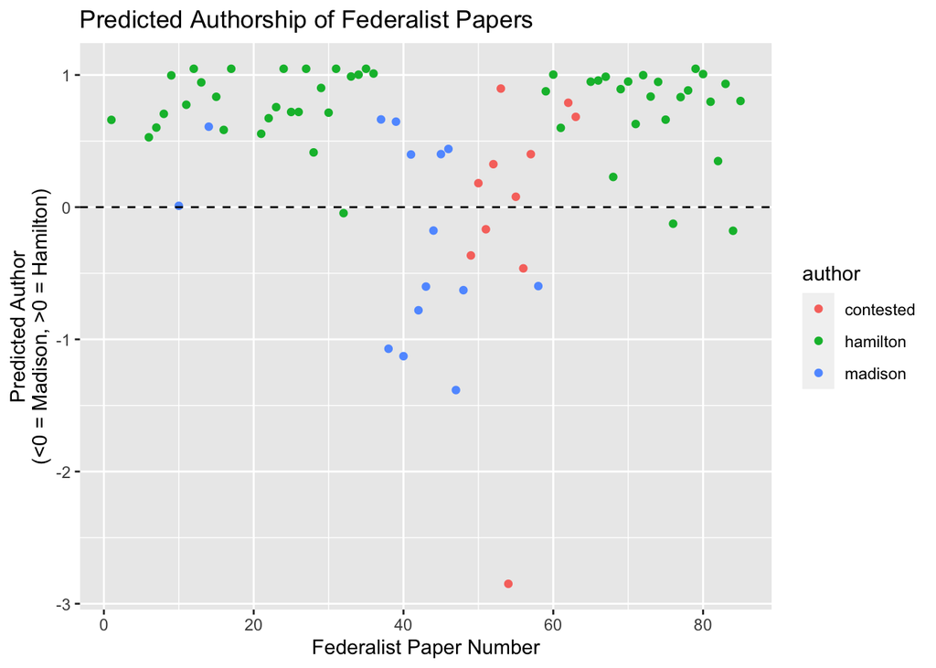

```r
toplotHam <- datSubset_ham5 %>%
  mutate(predAuthor = predict(mHam,newdata = datSubset_ham5)) # Predicting the authorship for every Federalist Paper (including the contested!)
toplotHam %>%
  filter(author %in% c('contested','madison','hamilton')) %>% # Plotting only the papers written by Hamilton, Madison, or contested
  ggplot(aes(x = document,y = predAuthor,color = author)) +  # Color points by author
  geom_point() +
  geom_hline(yintercept = 0,linetype = 'dashed') +
  labs(title = 'Predicted Authorship of Federalist Papers',
       x = 'Federalist Paper Number',
       y = 'Predicted Author\n(<0 = Madison, >0 = Hamilton)')
```

> - Positive values on the y-axis mean that our model predicts the author to be Hamilton, while negative values mean that our model predicts Madison. Thus, since more contested documents lie above the dashed line, I think the consented documents were written by Hamilton.